# md

2022-12-01

# I.Setup

Libraries needed: [Note: I wrote results hide but the ## are not results maybe??]

```r
library(dplyr)
library(Seurat)
library(patchwork)
```

Loading data & Checking out how the loaded data looks like:

```r
mouse.data <- Read10X(data.dir = "/Users/xiaoyizheng/Downloads/Bioinformatik/Bioinfo_Einarbeiten/CellChatSelf/mouse/GSE113854_RAW/")

mouse.data
```

```
##   [[ suppressing 32 column names 'AAACCTGAGAATTCCC-1', 'AAACCTGAGACCGGAT-1', 'AAACCTGAGACGCACA-1' ... ]]
##   [[ suppressing 32 column names 'AAACCTGAGAATTCCC-1', 'AAACCTGAGACCGGAT-1', 'AAACCTGAGACGCACA-1' ... ]]
##   [[ suppressing 32 column names 'AAACCTGAGAATTCCC-1', 'AAACCTGAGACCGGAT-1', 'AAACCTGAGACGCACA-1' ... ]]
```

Creating Seurat object:

```r
mouse <- CreateSeuratObject(counts = mouse.data, project = "MoSk", min.cells = 3, min.features = 200)
```

# II. Pre-processing

QC (quality control) Matrix for selection and filtration of cells, using user-defined criteria. In this case it is the mitochondrial genes as criteria. [note: apparently they all have same level of mt content. Maybe pre-processed already? or maybe that is not the proper criteria to choose in this case. Which one could be better instead of it?]

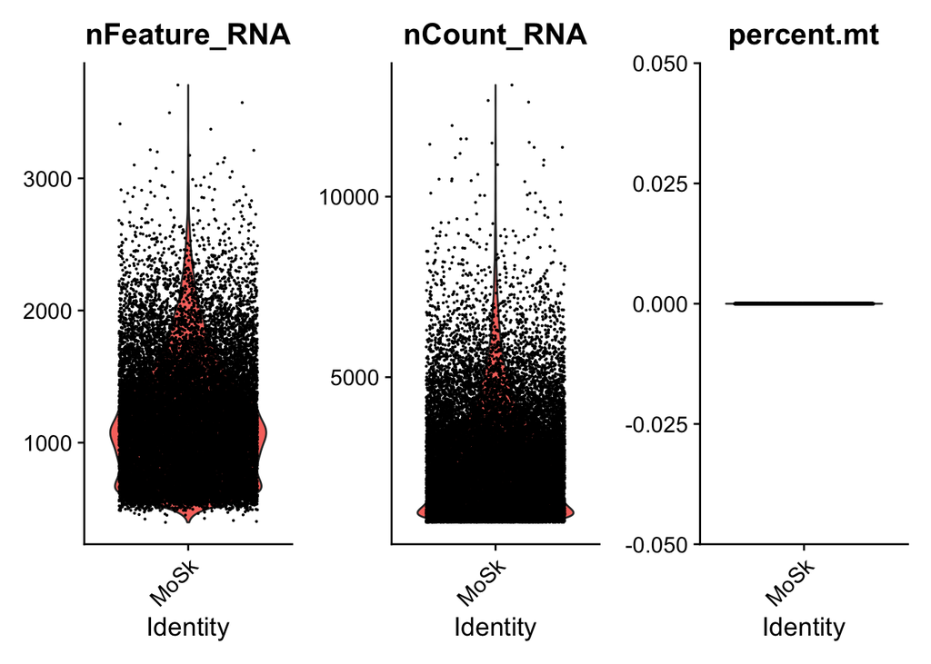

```r
mouse[["percent.mt"]] <- PercentageFeatureSet(mouse, pattern = "^MT-")

#Visualization by violin plot (mt percent no significance):
VlnPlot(mouse, features = c("nFeature_RNA", "nCount_RNA", "percent.mt"), ncol = 3)
```

Genes and total molecules calculated and stored in obj. meta data. Showing QC metrics for the first 5 cells:

```r
head(mouse@meta.data, 5)
```

```
##                    orig.ident nCount_RNA nFeature_RNA percent.mt
## AAACCTGAGAATTCCC-1       MoSk       1475          783          0
## AAACCTGAGACCGGAT-1       MoSk       4148         1624          0
## AAACCTGAGACGCACA-1       MoSk       3136         1342          0
## AAACCTGAGATGTGGC-1       MoSk       3138         1323          0
## AAACCTGAGCTGCGAA-1       MoSk       4029         1721          0
```

```r
#examining a few genes in the first thirty cells
mouse.data[c("Igf2", "Cck", "Pf4"), 1:30]
```

```
## 3 x 30 sparse Matrix of class "dgCMatrix"
```

```
##   [[ suppressing 30 column names 'AAACCTGAGAATTCCC-1', 'AAACCTGAGACCGGAT-1', 'AAACCTGAGACGCACA-1' ... ]]
```

```
##
## Igf2 . . . . . 1 . .  . . . . . .  . . . 1 . . . . . . . . . . . .
## Cck  . . . . . . . .  . . . . . .  . . . . . . . . . . . . . . . .
## Pf4  . . . . . . . . 11 . . . . . 25 . . 1 1 . 1 1 . 1 . . . . . 2
```

```r
#a few genes in the first 30 cells
#picked "Igf2", "Cck", "Pf4" according to web
```

### Visualization of feature-feature relationships

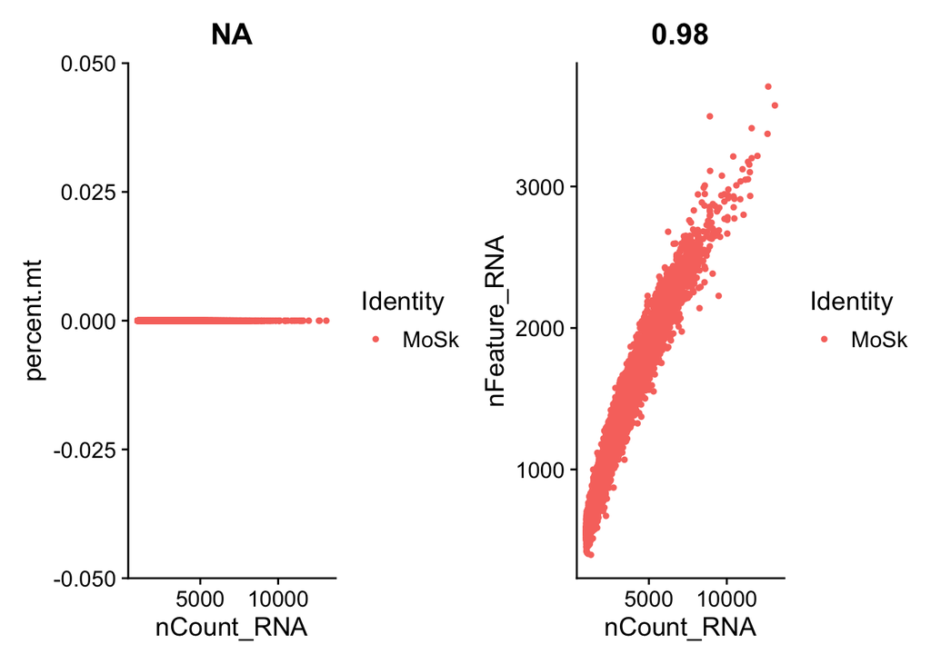

```r
plot1 <- FeatureScatter(mouse, feature1 = "nCount_RNA", feature2 = "percent.mt")
#since all have same mt quality...

plot2 <- FeatureScatter(mouse, feature1 = "nCount_RNA", feature2 = "nFeature_RNA")
#positively correlated

plot1 + plot2
```

# III. Normalization

since it is already normalized => this step omitted

# IV. Feature Selection

```r
mouse <- FindVariableFeatures(mouse, selection.method = "vst", nfeatures = 2000)
top10 <- head(VariableFeatures(mouse), 10) # Identify the 10 most highly variable genes
top10
```

```
##  [1] "Hbb-bs" "Hba-a1" "Ccl21a" "Hbb-bt" "Saa3"   "Acp5"   "Ccl5"   "S100a8"
##  [9] "Mmp9"   "S100a9"
```

```r
plot1 <- VariableFeaturePlot(mouse)
plot2 <- LabelPoints(plot = plot1, points = top10, repel = TRUE)
```

```
## When using repel, set xnudge and ynudge to 0 for optimal results
```

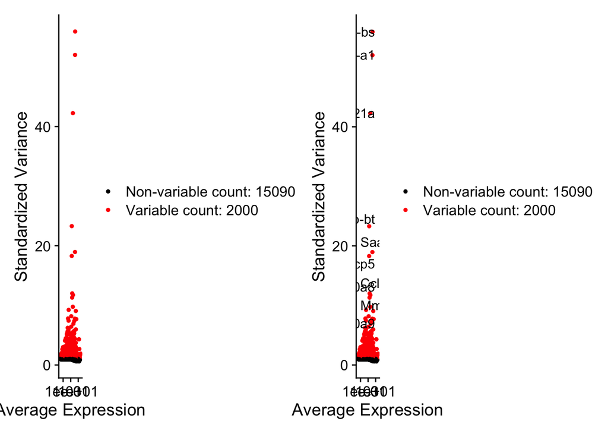

```r
plot1 + plot2
```

# V. Scaling

```r
all.genes <- rownames(mouse)
mouse <- ScaleData(mouse, features = all.genes)
#optional: mouse <- ScaleData(mouse)
```

# VI. Linear Dimension Reduction

### Perform PCA

```r
mouse <- RunPCA(mouse, features = VariableFeatures(object = mouse))
```

```
## PC_ 1
## Positive:  Sparc, Bgn, Col1a2, Col1a1, Col3a1, Col6a1, Lgals1, Serpinh1, Col5a2, Fstl1
##     Tmsb10, Col6a2, Col5a1, Col12a1, Aebp1, Dcn, Postn, Meg3, Fn1, Col6a3
##     Mmp2, Fbln2, Lum, S100a6, Fosb, Loxl1, Thbs2, Serpinf1, Lrrc15, Tuba1a
## Negative:  Tyrobp, Fcer1g, Lyz2, C1qb, Apoe, Ctss, C1qa, C1qc, Ms4a7, Aif1
##     Cd52, Pf4, Wfdc17, Laptm5, Fth1, Cd74, Ms4a6c, Lgals3, Clec4n, Cd68
##     Lst1, Alox5ap, H2-Aa, Ptpn18, Ucp2, Id2, AF251705, Trem2, Fcgr3, Clec4a2
## PC_ 2
## Positive:  Col1a1, Col1a2, Col3a1, Mfap4, Lum, Postn, Col5a2, Col12a1, Dcn, Thbs2
##     Igf1, Aebp1, Mdk, Mmp2, Itm2a, Col5a1, Spon1, Lox, Ptn, Olfml3
##     Dpt, Cthrc1, Fndc1, Aspn, Serpinf1, Lrrc15, Col6a2, Mfap5, Col6a1, Prss35
## Negative:  Cdh5, Col4a1, Col4a2, Pecam1, Egfl7, Igfbp7, Cd93, Crip2, Cav1, Ramp2
##     Plvap, Vim, Col15a1, Myct1, Kdr, Adgrf5, Esam, Pdlim1, Emcn, Ctla2a
##     Ecscr, Sparcl1, Col18a1, Eng, Adgrl4, Mcam, Itga6, Gimap6, Ehd4, F11r
## PC_ 3
## Positive:  Sparcl1, Rgs5, Il6, Tinagl1, Igfbp7, Col4a1, Col4a2, Gm13889, Fabp4, Ebf1
##     Ly6c1, Sept4, Emcn, Adgrf5, Ndufa4l2, Pecam1, Esam, Adgrl4, Flt1, Notch3
##     Adamts9, Epas1, Des, Bcr, Vtn, Mcam, 2200002D01Rik, Higd1b, Apold1, Cygb
## Negative:  Ftl1, Tyrobp, Fth1, Fcer1g, Lyz2, Cyba, Lgals3, Apoe, C1qb, Ctss
##     C1qc, C1qa, Cstb, Laptm5, Tmsb4x, Lst1, Ctsd, Pf4, Ms4a7, Cd68
##     Lgmn, Gm10116, Clec4n, Aif1, Wfdc17, Csf1r, Id2, Alox5ap, Ms4a6c, Ucp2
## PC_ 4
## Positive:  Rgs5, Ndufa4l2, Gm13889, Crip1, Acta2, Higd1b, Des, Notch3, Cox4i2, Thy1
##     Mylk, Pdgfa, S100a4, Serpine2, Ppp1r14a, Il6, Myl9, Rasgrp2, Ebf1, Tuba1b
##     2810417H13Rik, Cygb, Stmn1, Mgp, Ube2c, Mustn1, Cks2, Col4a1, Tpm1, H2afz
## Negative:  Mfap4, Cdh5, Pecam1, Igf1, Col1a2, Cd34, Cd93, Ptn, Col3a1, Col1a1
##     Ramp2, S100a16, Egfl7, Mest, Lum, Myct1, Dpt, Thbs2, Mdk, Itm2a
##     Aebp1, Col14a1, Kdr, Ly6c1, Ogn, Ctla2a, C1qtnf3, Adgrl4, Emcn, Plvap
## PC_ 5
## Positive:  Birc5, Stmn1, H2afz, Ube2c, Top2a, Hmgb2, Tuba1b, 2810417H13Rik, Cenpa, Cks2
##     Cdca3, 2700094K13Rik, Cks1b, Ccnb2, Tubb5, Hmgb1, Cdk1, H2afx, Smc2, Lockd
##     Ccnb1, Cdca8, Ccna2, Prc1, Ccdc34, H2afv, Ube2s, Hmgn2, Nusap1, Spc24
## Negative:  Rgs5, Cxcl1, Gm13889, Il6, Meg3, Serping1, Errfi1, Serpine2, Mylk, Col4a1
##     Notch3, Ndufa4l2, Ccl2, Ebf1, Mt1, Col4a2, Des, Neat1, Phlda1, Cygb
##     Dnajb1, Malat1, Apold1, Col18a1, Tnfaip2, Adamts4, Higd1b, Nr4a1, Sparcl1, Bcr
```

### Examine and visualize PCA results a few different ways

```r
print(mouse[["pca"]], dims = 1:5, nfeatures = 5)
```

```
## PC_ 1
## Positive:  Sparc, Bgn, Col1a2, Col1a1, Col3a1
## Negative:  Tyrobp, Fcer1g, Lyz2, C1qb, Apoe
## PC_ 2
## Positive:  Col1a1, Col1a2, Col3a1, Mfap4, Lum
## Negative:  Cdh5, Col4a1, Col4a2, Pecam1, Egfl7
## PC_ 3
## Positive:  Sparcl1, Rgs5, Il6, Tinagl1, Igfbp7
## Negative:  Ftl1, Tyrobp, Fth1, Fcer1g, Lyz2
## PC_ 4
## Positive:  Rgs5, Ndufa4l2, Gm13889, Crip1, Acta2
## Negative:  Mfap4, Cdh5, Pecam1, Igf1, Col1a2
## PC_ 5
## Positive:  Birc5, Stmn1, H2afz, Ube2c, Top2a
## Negative:  Rgs5, Cxcl1, Gm13889, Il6, Meg3
```

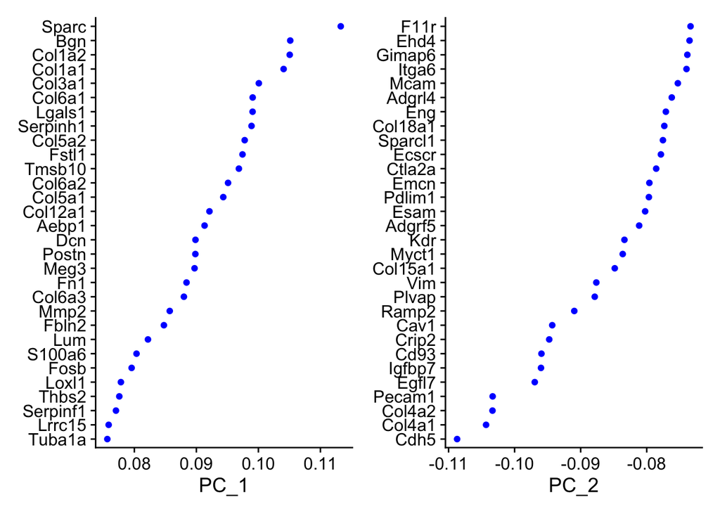

```r
VizDimLoadings(mouse, dims = 1:2, reduction = "pca")
```

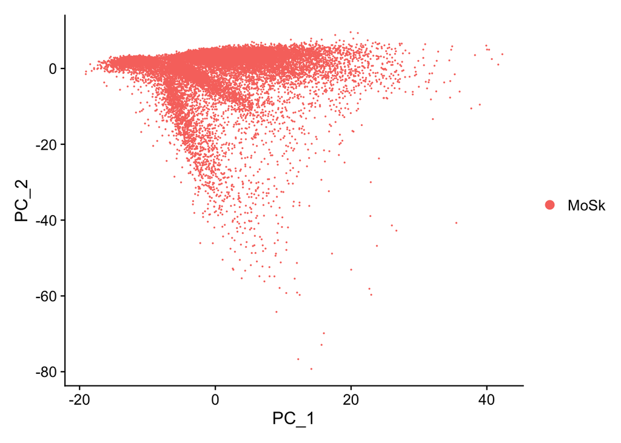

```r
DimPlot(mouse, reduction = "pca")
```

heatmap: exploration of the primary sources of heterogeneity -> decide which PCs to include for further downstream analyses

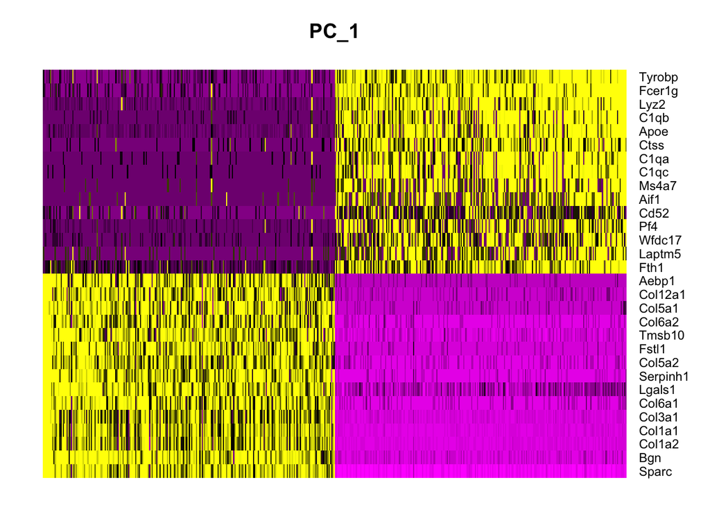

```r
DimHeatmap(mouse, dims = 1, cells = 500, balanced = TRUE) #heatmap: exploration of the primary sources of heterogeneity
```

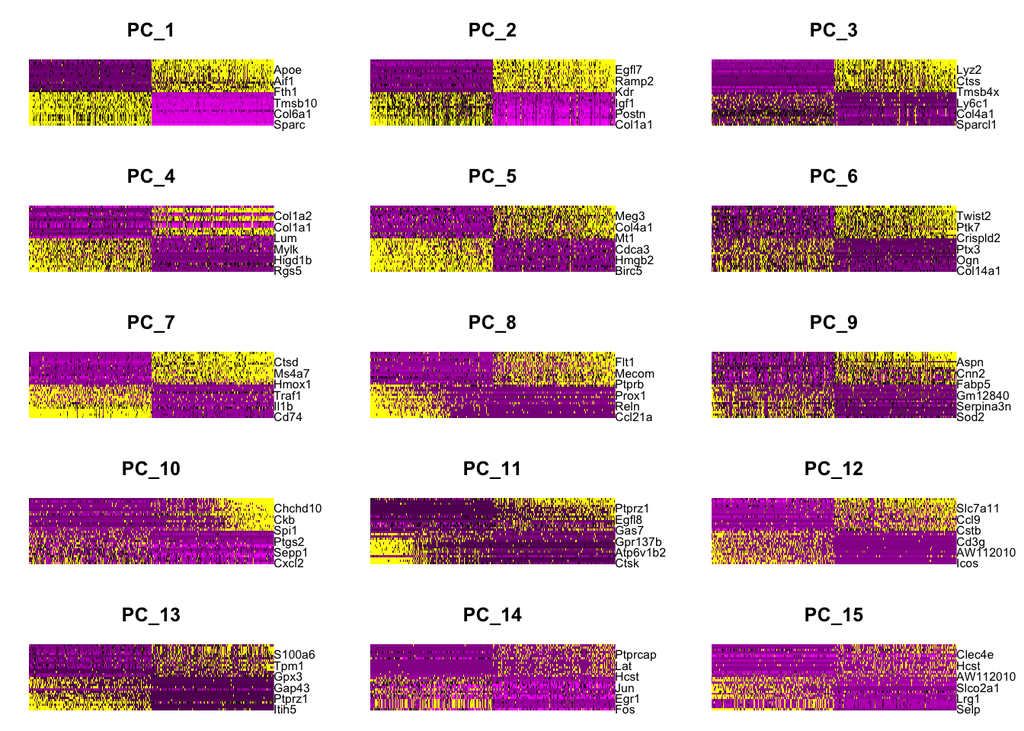

```r
DimHeatmap(mouse, dims = 1:15, cells = 500, balanced = TRUE)
```

# VII. Determination of Dimension Metafeature combines information across a correlated feature set. top principal components => robust compression how many PCs to take? ###JackStraw procedure permute subset of the data (1% by default) and rerun PCA significant PCs ~ strong enrichment of low p-value features

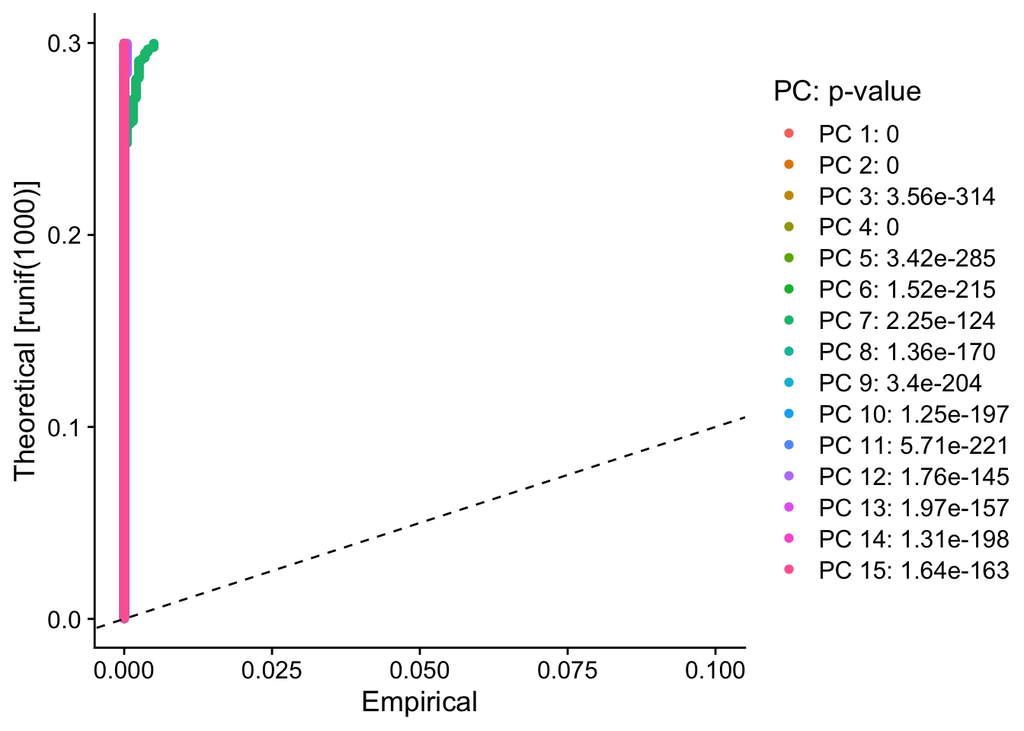

```r
mouse <- JackStraw(mouse, num.replicate = 100)
mouse <- ScoreJackStraw(mouse, dims = 1:20)
JackStrawPlot(mouse, dims = 1:15)
```

alternative heuristic method Elbow plot: observe where the elbow is and then see which PCs to choose

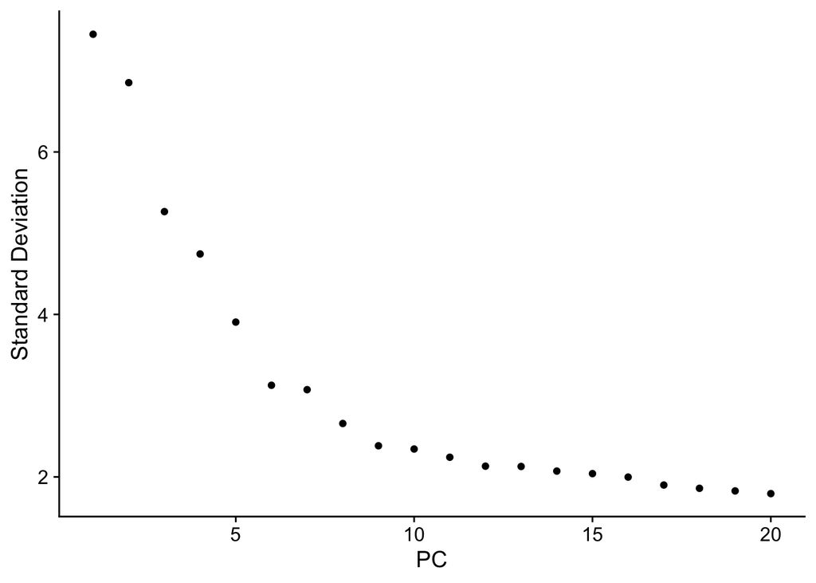

```r
ElbowPlot(mouse)
```

# VIII. Clustering Cells

# IX. Non-linear Dimension Reduction

# XI. Assigning Cell Type Identity to Clusters